# TidyTuesday 2026 Week 13 — Ocean Temperature Explorer

## 7. Data Quality — Where Are the Gaps?

Before drawing any conclusions it is worth knowing how complete the record is. The TidyTuesday readme flags that some days have no data; here we build the full expected grid of date × depth combinations and find what is missing.

```r
full_grid <- tidyr::expand_grid(
  date                       = seq(min(ocean_temperature$date),
                                   max(ocean_temperature$date),
                                   by = "day"),
  sensor_depth_at_low_tide_m = c(2, 5, 10, 15, 20, 30, 40)
)

missing <- full_grid |>
  dplyr::anti_join(
    ocean_temperature,
    by = c("date", "sensor_depth_at_low_tide_m")
  ) |>
  dplyr::mutate(year = lubridate::year(date))
```

### 7a. Missing depth-days per year

```r
missing |>
  dplyr::summarise(
    missing_depth_days = n(),
    missing_dates      = n_distinct(date),
    .by = year
  ) |>
  dplyr::arrange(year)
```

```
## # A tibble: 5 × 3
##    year missing_depth_days missing_dates
##   <dbl>              <int>         <int>
## 1  2019                146           146
## 2  2022                 58            58
## 3  2023                265           265
## 4  2024                286           202
## 5  2025                  9             9
```

### 7b. Which depths are affected?

```r
missing |>
  dplyr::summarise(
    missing_days = n(),
    .by = c(year, sensor_depth_at_low_tide_m)
  ) |>
  tidyr::pivot_wider(
    names_from   = sensor_depth_at_low_tide_m,
    values_from  = missing_days,
    values_fill  = 0,
    names_prefix = "d"
  ) |>
  dplyr::arrange(year)
```

```
## # A tibble: 5 × 4
##    year    d2   d40    d5
##   <dbl> <int> <int> <int>
## 1  2019   146     0     0
## 2  2022     0    58     0
## 3  2023     0   134   131
## 4  2024   202    33    51
## 5  2025     0     0     9
```

Only the **2 m, 5 m, and 40 m** sensors have gaps — the other four depths have complete records across the full eight years. This rules out full station outages; individual sensors are the issue.

### 7c. Missing data heatmap

This heatmap shows the percentage of days missing in each month, for each depth. White = fully complete; deep red = mostly missing.

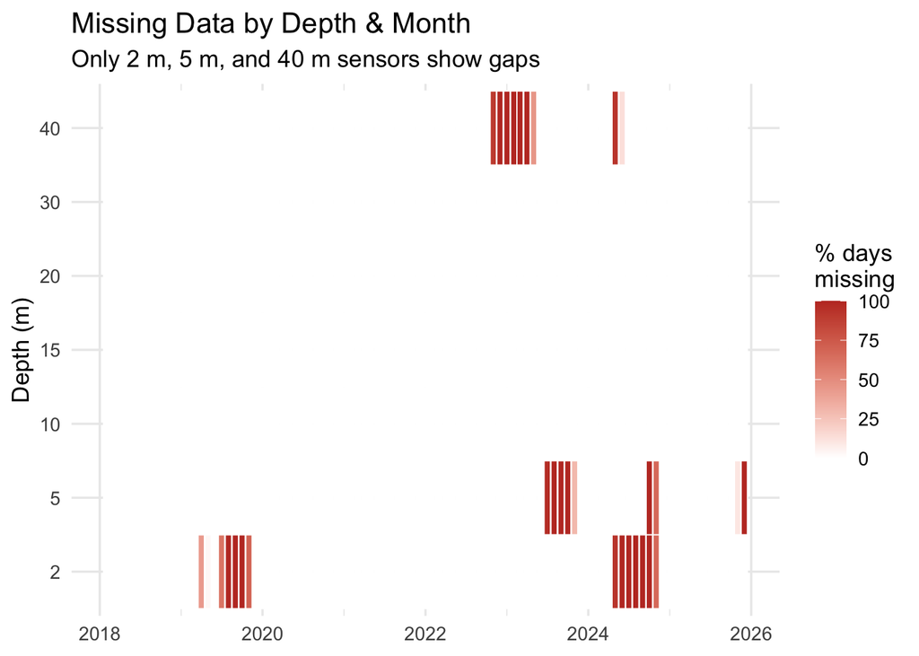

```r
full_grid |>
  dplyr::left_join(
    ocean_temperature |>
      dplyr::select(date, sensor_depth_at_low_tide_m) |>
      dplyr::mutate(has_data = TRUE),
    by = c("date", "sensor_depth_at_low_tide_m")
  ) |>
  dplyr::mutate(
    has_data = tidyr::replace_na(has_data, FALSE),
    month    = lubridate::floor_date(date, "month")
  ) |>
  dplyr::summarise(
    pct_missing = mean(!has_data) * 100,
    .by = c(month, sensor_depth_at_low_tide_m)
  ) |>
  ggplot(aes(
    x    = month,
    y    = factor(sensor_depth_at_low_tide_m),
    fill = pct_missing
  )) +
  geom_tile(color = "white", linewidth = 0.3) +
  scale_fill_gradient(
    low  = "white",
    high = "#c0392b",
    name = "% days\nmissing"
  ) +
  labs(
    title    = "Missing Data by Depth & Month",
    subtitle = "Only 2 m, 5 m, and 40 m sensors show gaps",
    x        = NULL,
    y        = "Depth (m)"
  ) +
  theme_minimal(base_size = 13)
```